# ReMis_Main_processed_Analysed

Marton Kovacs

18 August, 2021

# Load packages

```r
library(tidyverse)
library(readxl)
library(qdap)
library(papaja)
library(skimr)
library(viridis)
```

# Load functions

```r
source("utils.R")
```

# Descriptives of the sample

## Read in data

```r
descriptives <- read_tsv("Data/Processed/ReMis_Main_Processed_Descriptive_data.tsv")
```

## The number of distinct respondents

```r
descriptives %>%
  distinct(response_id) %>%
  count()
```

```
## # A tibble: 1 x 1
##       n
##   <int>
## 1   488
```

## Data descriptives

```r
skim(descriptives)
```

Data summary

| Name | descriptives |
| --- | --- |
| Number of rows | 488 |
| Number of columns | 3 |
| _______________________ |  |
| Column type frequency: |  |
| character | 2 |
| numeric | 1 |
| ________________________ |  |
| Group variables | None |

**Variable type: character**

| skim_variable | n_missing | complete_rate | min | max | empty | n_unique | whitespace |
| --- | --- | --- | --- | --- | --- | --- | --- |
| response_id | 0 | 1 | 17 | 17 | 0 | 488 | 0 |
| field | 0 | 1 | 5 | 44 | 0 | 9 | 0 |

**Variable type: numeric**

| skim_variable | n_missing | complete_rate | mean | sd | p0 | p25 | p50 | p75 | p100 | hist |
| --- | --- | --- | --- | --- | --- | --- | --- | --- | --- | --- |
| years | 0 | 1 | 18.2 | 10.99 | 1 | 10 | 15 | 25 | 58 | ▇▇▅▁▁ |

## Years in field descriptives

```r
descriptives %>%
  summarise(median_year = median(years, na.rm = TRUE))
```

```
## # A tibble: 1 x 1
##   median_year
##         <dbl>
## 1          15
```

## Years spent on the field

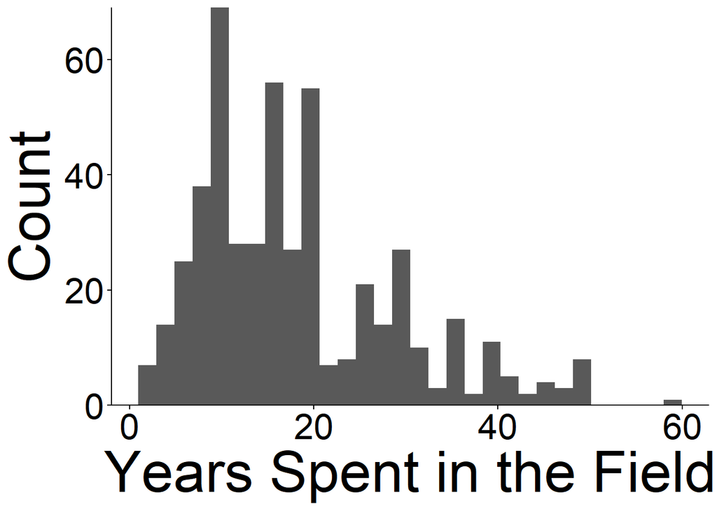

```r
### Histogram
descriptives %>%
  ggplot() +
  aes(years) +
  geom_histogram() +
  labs(x = "Years Spent in the Field",  y = "Count") +
  scale_y_continuous(expand = c(0,0)) +
  theme(axis.ticks = element_line(color = "black"),
        axis.line = element_line(color = "black"),
        axis.text = element_text(color = "black", size = 25),
        axis.title = element_text(size = 40),
        panel.background = element_blank())
```

Saving the plot.

```r
ggsave("Figures/figs2.png", plot = last_plot(), dpi = 300, width = 50, height = 30, units = "cm")
ggsave("Figures/figs2.pdf", plot = last_plot(), dpi = 300, width = 50, height = 30, units = "cm")
```

## Field

Distribution of the subfield of the respondents.

```r
descriptives %>%
  group_by(field) %>%
  summarise(n = n()) %>%
  ungroup() %>%
  mutate(N = sum(n),
         percentage = round(n / N * 100, 2)) %>%
  arrange(desc(n))
```

```
## # A tibble: 9 x 4
##   field                                            n     N percentage
##   <chr>                                        <int> <int>      <dbl>
## 1 other                                          116   488      23.8
## 2 experimental and cognitive psychology           88   488      18.0
## 3 social psychology                               62   488      12.7
## 4 clinical psychology                             45   488       9.22
## 5 developmental and educational psychology        45   488       9.22
## 6 applied psychology                              44   488       9.02
## 7 neurophysiology and physiological psychology    35   488       7.17
## 8 methodology and statistics                      33   488       6.76
## 9 personality psychology                          20   488       4.1
```

Plotting the distribution.

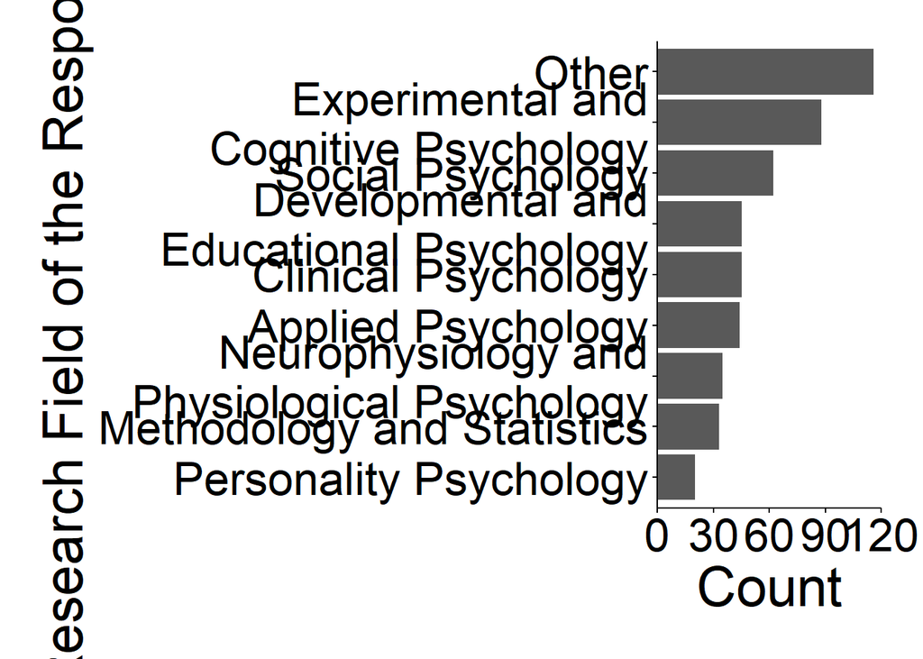

```r
descriptives %>%
  filter(!is.na(field)) %>%
  mutate(field = case_when(field == "other" ~ "Other",
                           field == "experimental and cognitive psychology" ~ "Experimental and\nCognitive Psychology",
                           field == "social psychology" ~ "Social Psychology",
                           field == "clinical psychology" ~ "Clinical Psychology",
                           field == "developmental and educational psychology" ~ "Developmental and\nEducational Psychology",
                           field == "applied psychology" ~ "Applied Psychology",
                           field == "neurophysiology and physiological psychology" ~ "Neurophysiology and\nPhysiological Psychology",
                           field == "methodology and statistics" ~ "Methodology and Statistics",
                           field == "personality psychology" ~ "Personality Psychology")) %>%
  group_by(field) %>%
  count() %>%
  ggplot(.) +
  aes(x = reorder(field, n), y = n) +
  geom_bar(stat = "identity") +
  scale_y_continuous(expand = c(0,0), limits = c(0, 120)) +
  labs(x = "Research Field of the Respondent",
       y = "Count") +
  coord_flip() +
  theme(
    # axis.text.x = element_text(angle = 45, hjust = 1, vjust = 1),
    axis.ticks = element_line(color = "black"),
    axis.line = element_line(color = "black"),
    axis.text = element_text(color = "black", size = 25),
    axis.title = element_text(size = 30),
    panel.background = element_blank(),
    plot.margin = unit(c(.8, .8, .8, .8), "cm"))
```

Saving the plot.

```r
ggsave("Figures/figs3.png", plot = last_plot(), dpi = 300, width = 50, height = 30, units = "cm")

ggsave("Figures/figs3.pdf", plot = last_plot(), dpi = 300, width = 50, height = 30, units = "cm")
```

# General overview of data management mistakes

## General frequency of mistakes

### Import data

```r
general_mistake_frequency <- read_tsv("Data/Processed/ReMis_Main_Processed_General_Frequency_data.tsv")
```

### Relevel factor variable for plotting

```r
general_mistake_frequency <-
  general_mistake_frequency %>%
  mutate(general_frequency = frequency_char_to_fact(general_frequency))
```

Checking the levels of the answer option to general_frequency.

```r
distinct(general_mistake_frequency, general_frequency)
```

```
## # A tibble: 5 x 1
##   general_frequency
##   <fct>
## 1 Very Low
## 2 Low
## 3 Moderate
## 4 High
## 5 Very High
```

### Descriptive results

```r
general_mistake_frequency %>%
  filter(!is.na(general_frequency)) %>%
  group_by(general_frequency) %>%
  summarise(n = n()) %>%
  ungroup() %>%
  mutate(N = sum(n),
         percentage = round(n / N * 100, 0))
```

```
## # A tibble: 5 x 4
##   general_frequency     n     N percentage
##   <fct>             <int> <int>      <dbl>
## 1 Very Low            137   486         28
## 2 Low                 247   486         51
## 3 Moderate             68   486         14
## 4 High                 24   486          5
## 5 Very High            10   486          2
```

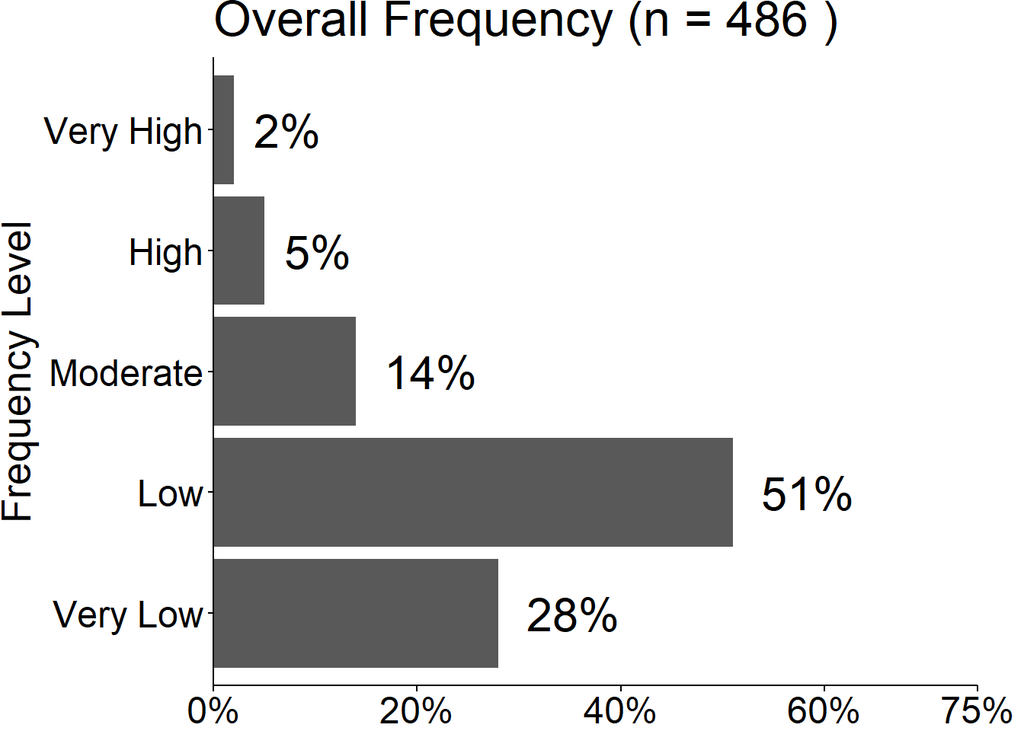

```r
# With percentage
general_mistake_frequency_plot_data <-
  general_mistake_frequency %>%
  filter(!is.na(general_frequency)) %>%
  group_by(general_frequency) %>%
  summarise(n = n()) %>%
  ungroup() %>%
  mutate(N = sum(n),
         percentage = round(n / N * 100, 0))

general_mistake_frequency_all_n <- sum(general_mistake_frequency_plot_data$n)

general_mistake_frequency_plot <-
  general_mistake_frequency_plot_data %>%
  ggplot() +
  aes(x = general_frequency, y = percentage) +
  geom_bar(stat = "identity") +
  geom_text(aes(label = paste0(percentage, "%")), size = 8, hjust=-0.3) +
  scale_y_continuous(expand = c(0,0), limit = c(0, 75), breaks = c(0, 20, 40, 60, 75), labels = scales::label_percent(scale = 1)) +
  labs(x = "Frequency Level",
       title = paste("Overall Frequency (n =", general_mistake_frequency_all_n, ")")) +
  coord_flip() +
  theme(axis.ticks = element_line(color = "black"),
        axis.line = element_line(color = "black"),
        axis.text = element_text(color = "black", size = 18),
        axis.title = element_text(size = 20),
        panel.background = element_blank(),
        axis.title.x = element_blank(),
        plot.margin = unit(c(0,0.8,0,0), "cm"),
        title = element_text(color = "black", size = 20))

general_mistake_frequency_plot
```

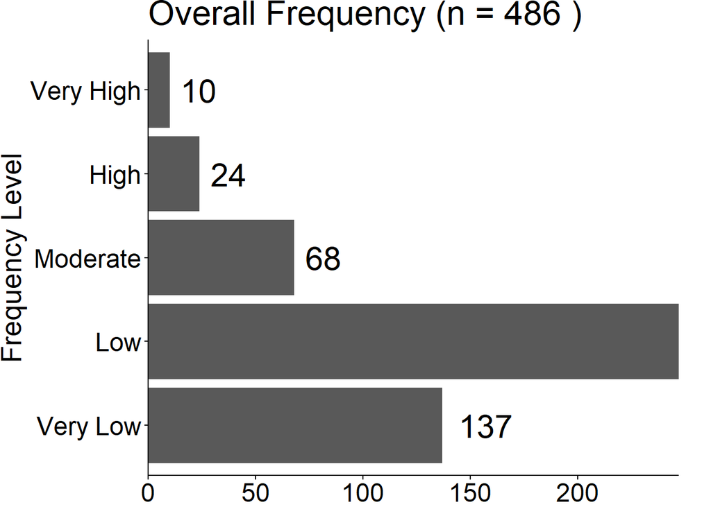

```r
# With count
general_mistake_frequency_plot_count <-
  general_mistake_frequency_plot_data %>%
  ggplot() +
  aes(x = general_frequency, y = n) +
  geom_bar(stat = "identity") +
  geom_text(aes(label = n), size = 8, hjust = -0.3) +
  scale_y_continuous(expand = c(0,0)) +
  labs(x = "Frequency Level",
       title = paste("Overall Frequency (n =", general_mistake_frequency_all_n, ")")) +
  coord_flip() +
  theme(axis.ticks = element_line(color = "black"),
        axis.line = element_line(color = "black"),
        axis.text = element_text(color = "black", size = 18),
        axis.title = element_text(size = 20),
        panel.background = element_blank(),
        axis.title.x = element_blank(),
        plot.margin = unit(c(0,0.8,0,0), "cm"),
        title = element_text(color = "black", size = 20))

general_mistake_frequency_plot_count
```

```r
general_mistake_frequency %>%
  filter(!is.na(general_frequency)) %>%
  mutate(report_group = case_when(general_frequency == "Very Low" ~ 1L,
                                  general_frequency == "Low" ~ 1L,
                                  general_frequency == "Moderate" ~ 0L,
                                  general_frequency == "High" ~ 0L,
                                  general_frequency == "Very High" ~ 0L)) %>%
  group_by(report_group) %>%
  summarise(n = n()) %>%
  ungroup() %>%
  mutate(N = sum(n),
         prop = n / N * 100)
```

```
## # A tibble: 2 x 4
##   report_group     n     N  prop
##          <int> <int> <int> <dbl>
## 1            0   102   486  21.0
## 2            1   384   486  79.0
```

## Analysis of the most frequent mistakes

### Read in data

```r
general_mistake_overview <- read_tsv("Data/Processed/ReMis_Main_Processed_Mistake_General_data.tsv")
```

### Number of responses to each investigated question

```r
general_mistake_overview %>%
  group_by(type, question) %>%
  count()
```

```
## # A tibble: 3 x 3
## # Groups:   type, question [3]
##   type      question      n
##   <chr>     <chr>     <int>
## 1 recurring frequency   419
## 2 recurring serious     419
## 3 serious   serious     296
```

### Levels of the answer option to recurring_frequency

```r
general_mistake_overview %>%
  filter(type == "recurring",
         question == "frequency") %>%
  distinct(rating)
```

```
## # A tibble: 5 x 1
##   rating
##   <chr>
## 1 Low
## 2 Very Low
## 3 Moderate
## 4 High
## 5 Very High
```

### Proportion of the frequency of the most recurring mistakes

```r
general_mistake_overview %>%
  filter(type == "recurring",
         question == "frequency",
         !is.na(rating)) %>%
  mutate(rating = frequency_char_to_fact(rating)) %>%
  group_by(rating) %>%
  summarise(n = n()) %>%
  ungroup() %>%
  mutate(N = sum(n),
         percentage = round(n / N * 100, 0))
```

```
## # A tibble: 5 x 4
##   rating        n     N percentage
##   <fct>     <int> <int>      <dbl>
## 1 Very Low     86   419         21
## 2 Low         228   419         54
## 3 Moderate     72   419         17
## 4 High         22   419          5
## 5 Very High    11   419          3
```

### Barplot of responses of the frequency of the most recurring mistakes

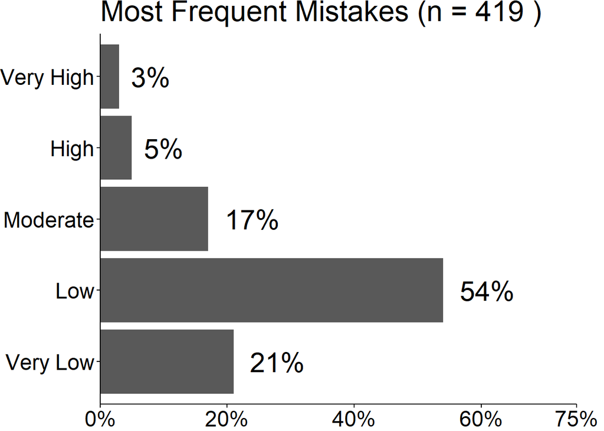

```r
# With percentage
most_frequent_frequency_plot_data <-
  general_mistake_overview %>%
  filter(type == "recurring",
         question == "frequency",
         !is.na(rating)) %>%
  mutate(rating = frequency_char_to_fact(rating)) %>%
  group_by(rating) %>%
  summarise(n = n()) %>%
  ungroup() %>%
  mutate(N = sum(n),
         percentage = round(n / N * 100, 0))

most_frequent_frequency_all_n <- sum(most_frequent_frequency_plot_data$n)

most_frequent_frequency_plot <-
  most_frequent_frequency_plot_data %>%
  ggplot() +
  aes(x = rating, y = percentage) +
  geom_bar(stat = "identity") +
  geom_text(aes(label = paste0(percentage, "%")), size = 8, hjust=-0.3) +
  labs(title = paste("Most Frequent Mistakes (n =", most_frequent_frequency_all_n, ")")) +
  scale_y_continuous(expand = c(0,0), limit = c(0, 75), breaks = c(0, 20, 40, 60, 75), labels = scales::label_percent(scale = 1)) +
  coord_flip() +
  theme(axis.ticks = element_line(color = "black"),
        axis.line = element_line(color = "black"),
        axis.text = element_text(color = "black", size = 18),
        panel.background = element_blank(),
        axis.title = element_blank(),
        plot.margin = unit(c(0,0.8,0,0), "cm"),
        title = element_text(color = "black", size = 20))

most_frequent_frequency_plot
```

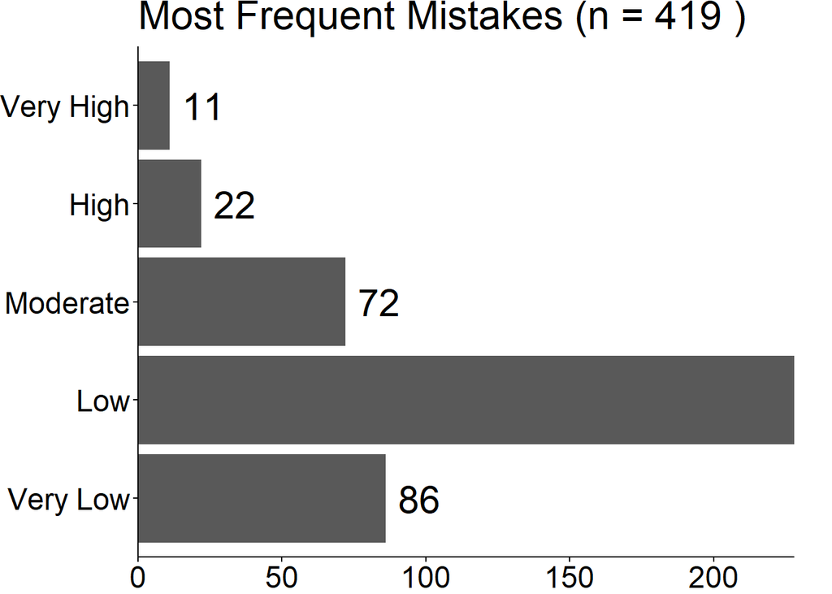

```r
# With counts
most_frequent_frequency_plot_count <-
  most_frequent_frequency_plot_data %>%
  ggplot() +
  aes(x = rating, y = n) +
  geom_bar(stat = "identity") +
  geom_text(aes(label = n), size = 8, hjust=-0.3) +
  labs(title = paste("Most Frequent Mistakes (n =", most_frequent_frequency_all_n, ")")) +
  scale_y_continuous(expand = c(0,0)) +
  coord_flip() +
  theme(axis.ticks = element_line(color = "black"),
        axis.line = element_line(color = "black"),
        axis.text = element_text(color = "black", size = 18),
        panel.background = element_blank(),
        axis.title = element_blank(),
        plot.margin = unit(c(0,0.8,0,0), "cm"),
        title = element_text(color = "black", size = 20))

most_frequent_frequency_plot_count
```

```r
general_mistake_overview %>%
  filter(type == "recurring",
         question == "frequency",
         !is.na(rating)) %>%
  mutate(rating = frequency_char_to_fact(rating)) %>%
  mutate(report_group = case_when(rating == "Very Low" ~ 1L,
                                  rating == "Low" ~ 1L,
                                  rating == "Moderate" ~ 0L,
                                  rating == "High" ~ 0L,
                                  rating == "Very High" ~ 0L)) %>%
  group_by(report_group) %>%
  summarise(n = n()) %>%
  ungroup() %>%
  mutate(N = sum(n),
         prop = n / N * 100)
```

```
## # A tibble: 2 x 4
##   report_group     n     N  prop
##          <int> <int> <int> <dbl>
## 1            0   105   419  25.1
## 2            1   314   419  74.9
```

### Levels of the answer option to recurring_serious

```r
general_mistake_overview %>%
  filter(type == "recurring",
         question == "serious") %>%
  distinct(rating)
```

```
## # A tibble: 5 x 1
##   rating
##   <chr>
## 1 Minor
## 2 Major
## 3 Moderate
## 4 Insignificant
## 5 Extreme
```

### Proportion of the most recurring mistakes on a given seriousness level throughout research data management

```r
general_mistake_overview %>%
  filter(type == "recurring",
         question == "serious",
         !is.na(rating)) %>%
  mutate(rating = serious_char_to_fact(rating)) %>%
  group_by(rating) %>%
  summarise(n = n()) %>%
  ungroup() %>%
  mutate(N = sum(n),
         percentage = n / N * 100)
```

```
## # A tibble: 5 x 4
##   rating            n     N percentage
##   <fct>         <int> <int>      <dbl>
## 1 Insignificant    34   419      8.11
## 2 Minor           255   419     60.9
## 3 Moderate        104   419     24.8
## 4 Major            24   419      5.73
## 5 Extreme           2   419      0.477
```

### Barplot of responses of the seriousness of the most recurring mistakes

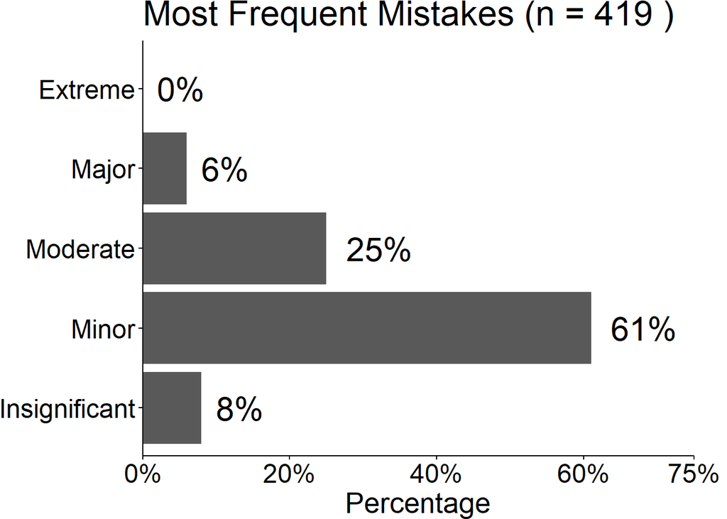

```r
# With percentage
most_frequent_seriousness_plot_data <-
  general_mistake_overview %>%
  filter(type == "recurring",
         question == "serious",
         !is.na(rating)) %>%
  mutate(rating = serious_char_to_fact(rating)) %>%
  group_by(rating) %>%
  summarise(n = n()) %>%
  ungroup() %>%
  mutate(N = sum(n),
         percentage = round(n / N * 100, 0))

most_frequent_seriousness_all_n <- sum(most_frequent_seriousness_plot_data$n)

most_frequent_seriousness_plot <-
  most_frequent_seriousness_plot_data %>%
  ggplot() +
  aes(rating, percentage) +
  geom_bar(stat = "identity") +
  geom_text(aes(label = paste0(percentage, "%")), size = 8, hjust = -0.3) +
  scale_y_continuous(expand = c(0,0), limit = c(0, 75), breaks = c(0, 20, 40, 60, 75), labels = scales::label_percent(scale = 1)) +
  labs(y = "Percentage",
       title = paste("Most Frequent Mistakes (n =", most_frequent_seriousness_all_n, ")")) +
  coord_flip() +
  theme(axis.ticks = element_line(color = "black"),
        axis.line = element_line(color = "black"),
        axis.text = element_text(color = "black", size = 18),
        axis.title = element_text(size = 20),
        panel.background = element_blank(),
        axis.title.y = element_blank(),
        plot.margin = unit(c(0,0.8,0,0), "cm"),
        title = element_text(color = "black", size = 20))

most_frequent_seriousness_plot
```

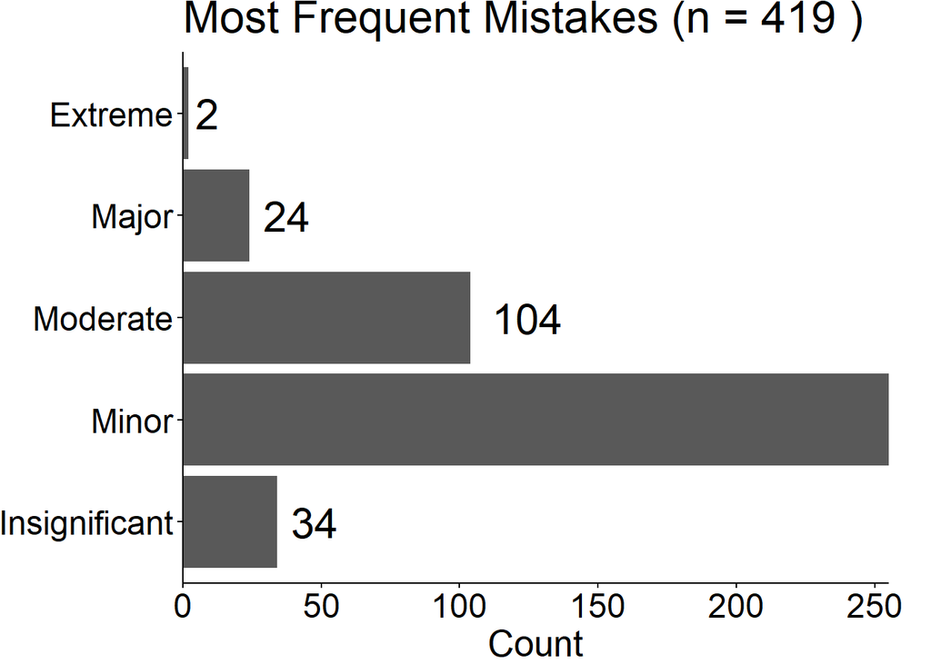

```r
# With count
most_frequent_seriousness_plot_count <-
  most_frequent_seriousness_plot_data %>%
    ggplot() +
  aes(rating, n) +
  geom_bar(stat = "identity") +
  geom_text(aes(label = n), size = 8, hjust = -0.3) +
  scale_y_continuous(expand = c(0,0)) +
  labs(y = "Count",
       title = paste("Most Frequent Mistakes (n =", most_frequent_seriousness_all_n, ")")) +
  coord_flip() +
  theme(axis.ticks = element_line(color = "black"),
        axis.line = element_line(color = "black"),
        axis.text = element_text(color = "black", size = 18),
        axis.title = element_text(size = 20),
        panel.background = element_blank(),
        axis.title.y = element_blank(),
        plot.margin = unit(c(0,0.8,0,0), "cm"),
        title = element_text(color = "black", size = 20))

most_frequent_seriousness_plot_count
```

```r
general_mistake_overview %>%
  filter(type == "recurring",
         question == "serious",
         !is.na(rating)) %>%
  mutate(rating = serious_char_to_fact(rating)) %>%
  mutate(report_group = case_when(rating == "Insignificant" ~ 1L,
                                  rating == "Minor" ~ 1L,
                                  rating == "Moderate" ~ 2L,
                                  rating == "Major" ~ 0L,
                                  rating == "Extreme" ~ 0L)) %>%
  group_by(report_group) %>%
  summarise(n = n()) %>%
  ungroup() %>%
  mutate(N = sum(n),
         prop = n / N * 100)
```

```
## # A tibble: 3 x 4
##   report_group     n     N  prop
##          <int> <int> <int> <dbl>
## 1            0    26   419  6.21
## 2            1   289   419 69.0
## 3            2   104   419 24.8
```

### Median rating of all the most recurring mistakes

```r
general_mistake_overview %>%
  filter(type == "recurring",
         !is.na(rating)) %>%
  mutate(rating = serious_char_to_int(rating)) %>%
  group_by(question) %>%
  summarize(median = median(rating, na.rm = TRUE),
            max = max(rating, na.rm = TRUE),
            min = min(rating, na.rm = TRUE),
            n = n(),
            quart1 = quantile(rating, 0.25, na.rm = TRUE),
            quart3 = quantile(rating, 0.75, na.rm = TRUE),
            IQR = IQR(rating, na.rm = TRUE))
```

```
## # A tibble: 2 x 8
##   question  median   max   min     n quart1 quart3   IQR
##   <chr>      <dbl> <int> <int> <int>  <dbl>  <dbl> <dbl>
## 1 frequency      3     3     3   419      3      3     0
## 2 serious        2     5     1   419      2      3     1
```

## Analysis of the most serious mistakes

### Proportion of the most serious mistakes on a given seriousness level throughout research data management

```r
general_mistake_overview %>%
  filter(type == "serious",
         question == "serious",
         !is.na(rating)) %>%
  mutate(rating = serious_char_to_fact(rating)) %>%
  group_by(rating) %>%
  summarise(n = n()) %>%
  ungroup() %>%
  mutate(N = sum(n),
         percentage = round(n / N * 100, 0))
```

```
## # A tibble: 5 x 4
##   rating            n     N percentage
##   <fct>         <int> <int>      <dbl>
## 1 Insignificant    10   296          3
## 2 Minor            83   296         28
## 3 Moderate        137   296         46
## 4 Major            60   296         20
## 5 Extreme           6   296          2
```

### Barplot of responses to serious_serious

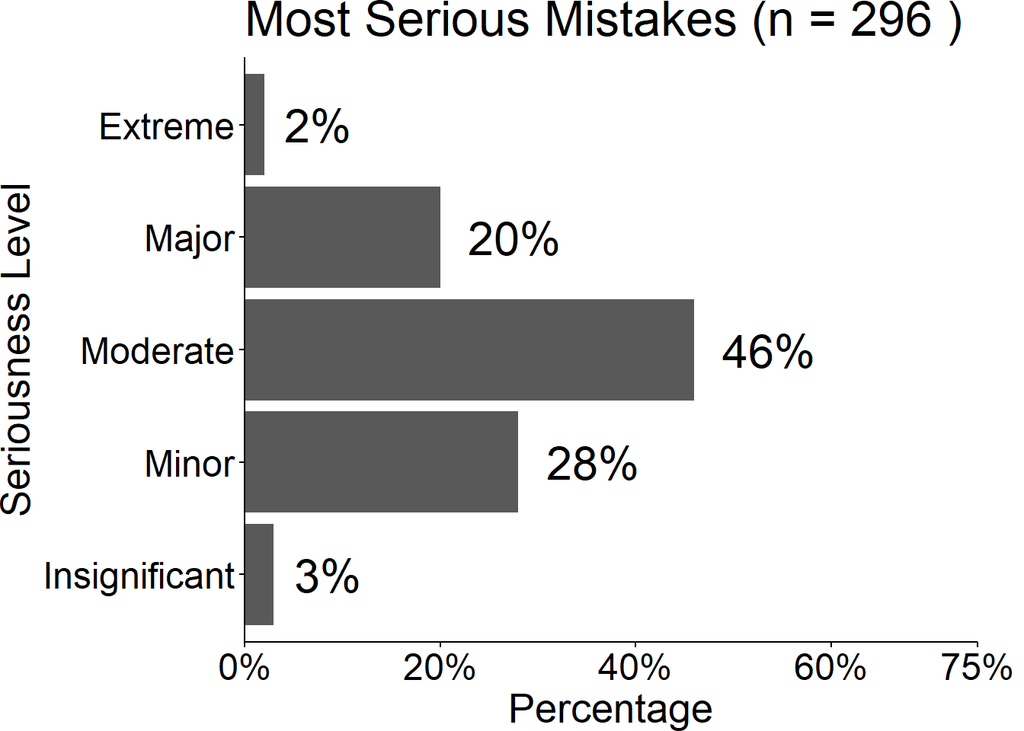

```r
# With percentage
most_serious_seriousness_plot_data <-
  general_mistake_overview %>%
  filter(type == "serious",
         question == "serious",
         !is.na(rating)) %>%
  mutate(rating = serious_char_to_fact(rating)) %>%
  group_by(rating) %>%
  summarise(n = n()) %>%
  ungroup() %>%
  mutate(N = sum(n),
         percentage = round(n / N * 100, 0))

most_serious_seriousness_all_n <- sum(most_serious_seriousness_plot_data$n)

most_serious_seriousness_plot <-
  most_serious_seriousness_plot_data %>%
  ggplot() +
  aes(rating, percentage) +
  geom_bar(stat = "identity") +
  geom_text(aes(label = paste0(percentage, "%")), size = 8, hjust=-0.3) +
  scale_y_continuous(expand = c(0,0), limit = c(0, 75), breaks = c(0, 20, 40, 60, 75), labels = scales::label_percent(scale = 1)) +
  labs(x = "Seriousness Level",
       y = "Percentage",
       title = paste("Most Serious Mistakes (n =", most_serious_seriousness_all_n, ")")) +
  coord_flip() +
  theme(axis.ticks = element_line(color = "black"),
        axis.line = element_line(color = "black"),
        axis.text = element_text(color = "black", size = 18),
        axis.title = element_text(size = 20),
        panel.background = element_blank(),
        plot.margin = unit(c(0,0.8,0,0), "cm"),
        title = element_text(color = "black", size = 20))

most_serious_seriousness_plot
```

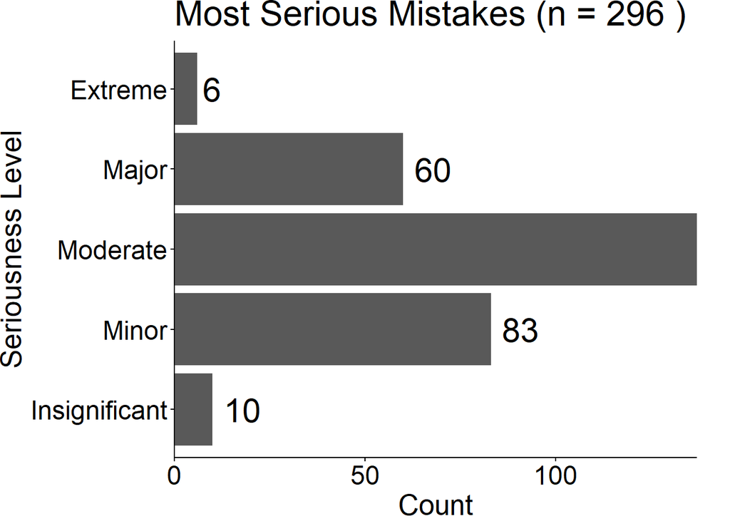

```r
# With count
most_serious_seriousness_plot_count <-
  most_serious_seriousness_plot_data %>%
    ggplot() +
  aes(rating, n) +
  geom_bar(stat = "identity") +
  geom_text(aes(label = n), size = 8, hjust = -0.3) +
  scale_y_continuous(expand = c(0,0)) +
  labs(x = "Seriousness Level",
       y = "Count",
       title = paste("Most Serious Mistakes (n =", most_serious_seriousness_all_n, ")")) +
  coord_flip() +
  theme(axis.ticks = element_line(color = "black"),
        axis.line = element_line(color = "black"),
        axis.text = element_text(color = "black", size = 18),
        axis.title = element_text(size = 20),
        panel.background = element_blank(),
        plot.margin = unit(c(0,0.8,0,0), "cm"),
        title = element_text(color = "black", size = 20))

most_serious_seriousness_plot_count
```

```r
general_mistake_overview %>%
  filter(type == "serious",
         question == "serious",
         !is.na(rating)) %>%
  mutate(rating = serious_char_to_fact(rating)) %>%
  mutate(report_group = case_when(rating == "Insignificant" ~ 1L,
                                  rating == "Minor" ~ 1L,
                                  rating == "Moderate" ~ 2L,
                                  rating == "Major" ~ 0L,
                                  rating == "Extreme" ~ 0L)) %>%
  group_by(report_group) %>%
  summarise(n = n()) %>%
  ungroup() %>%
  mutate(N = sum(n),
         prop = n / N * 100)
```

```
## # A tibble: 3 x 4
##   report_group     n     N  prop
##          <int> <int> <int> <dbl>
## 1            0    66   296  22.3
## 2            1    93   296  31.4
## 3            2   137   296  46.3
```

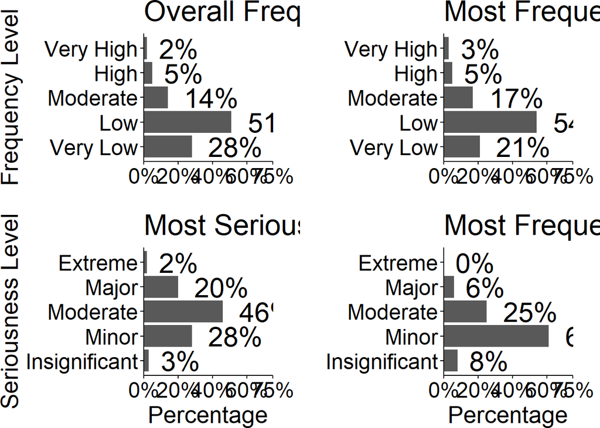

```r
cowplot::plot_grid(general_mistake_frequency_plot, most_frequent_frequency_plot,
                   most_serious_seriousness_plot, most_frequent_seriousness_plot, ncol = 2, align = "hv")
```

```r
ggsave("Figures/fig3.png", width = 14.4, height = 9, plot = last_plot())

ggsave("Figures/fig3.pdf", width = 14.4, height = 9, plot = last_plot())
```

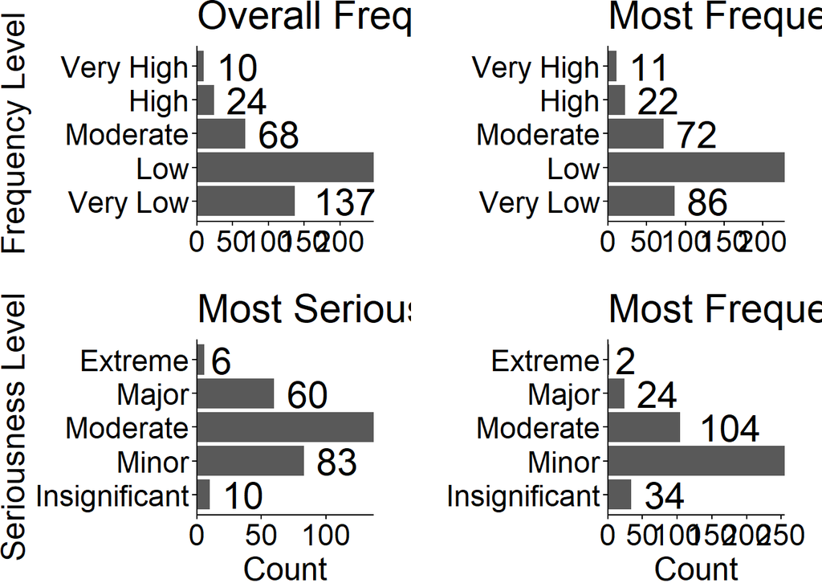

```r
cowplot::plot_grid(general_mistake_frequency_plot_count, most_frequent_frequency_plot_count,
                   most_serious_seriousness_plot_count, most_frequent_seriousness_plot_count, ncol = 2, align = "hv")
```

```r
ggsave("Figures/figs4.png", width = 14.4, height = 9, plot = last_plot())

ggsave("Figures/figs4.pdf", width = 14.4, height = 9, plot = last_plot())
```

# Investigating research data management mistake types

## Relationship between mistake types by mistake causes

### Read in processed data

```r
cause_type_relationship <- read_tsv( "Data/Processed/ReMis_Main_Processed_Cause_Type_Relationship_Analysis_data.tsv")
```

### Data descriptives

```r
skim(cause_type_relationship) %>% summary()
```

Data summary

| Name | cause_type_relationship |
| --- | --- |
| Number of rows | 509 |
| Number of columns | 14 |
| _______________________ |  |
| Column type frequency: |  |
| character | 12 |
| numeric | 2 |
| ________________________ |  |
| Group variables | None |

```r
skim(cause_type_relationship)
```

Data summary

| Name | cause_type_relationship |
| --- | --- |
| Number of rows | 509 |
| Number of columns | 14 |
| _______________________ |  |
| Column type frequency: |  |
| character | 12 |
| numeric | 2 |
| ________________________ |  |
| Group variables | None |

**Variable type: character**

| skim_variable | n_missing | complete_rate | min | max | empty | n_unique | whitespace |
| --- | --- | --- | --- | --- | --- | --- | --- |
| response_id | 0 | 1 | 17 | 17 | 0 | 298 | 0 |
| cause | 0 | 1 | 5 | 498 | 0 | 375 | 0 |
| cause_sep | 0 | 1 | 5 | 498 | 0 | 441 | 0 |
| maximum_response_one_cause | 0 | 1 | 2 | 3 | 0 | 2 | 0 |
| type | 0 | 1 | 7 | 9 | 0 | 2 | 0 |
| group_cause | 0 | 1 | 11 | 31 | 0 | 15 | 0 |
| code_cause | 0 | 1 | 5 | 62 | 0 | 169 | 0 |
| mistake | 0 | 1 | 4 | 733 | 0 | 384 | 0 |
| mistake_sep | 0 | 1 | 4 | 733 | 0 | 417 | 0 |
| maximum_response_one_type | 0 | 1 | 2 | 3 | 0 | 2 | 0 |
| group_type | 0 | 1 | 15 | 40 | 0 | 20 | 0 |
| code_type | 0 | 1 | 4 | 69 | 0 | 196 | 0 |

**Variable type: numeric**

| skim_variable | n_missing | complete_rate | mean | sd | p0 | p25 | p50 | p75 | p100 | hist |
| --- | --- | --- | --- | --- | --- | --- | --- | --- | --- | --- |
| cause_no | 0 | 1 | 1.25 | 0.55 | 1 | 1 | 1 | 1 | 5 | ▇▂▁▁▁ |
| mistake_no | 0 | 1 | 1.10 | 0.49 | 1 | 1 | 1 | 1 | 7 | ▇▁▁▁▁ |

### Data transformation

For the plot we are recoding the different cause groups to match APA 6th format.

```r
cause_type_relationship <-
  cause_type_relationship %>%
  mutate(group_cause_meta = case_when(group_cause == "lack of knowledge/experience" ~ "Lack of knowledge",
                                      group_cause == "bad or lack of planning" ~ "Poor project preparation\nor management",
                                      group_cause == "bad or lack of standards" ~ "Poor project preparation\nor management",
                                      group_cause == "bad skill management" ~ "Poor project preparation\nor management",
                                      group_cause == "miscommunication" ~ "Poor project preparation\nor management",
                                      group_cause == "project management issue" ~ "Poor project preparation\nor management",
                                      group_cause == "time management issue" ~ "Poor project preparation\nor management",
                                      group_cause == "risking human error" ~ "Poor project preparation\nor management",
                                      group_cause == "technical issue" ~ "External difficulties",
                                      group_cause == "too high complexity" ~ "External difficulties",
                                      group_cause == "inattention" ~ "Personal difficulties",
                                      group_cause == "carelessness" ~ "Personal difficulties",
                                      group_cause == "overconfidence" ~ "Personal difficulties",
                                      group_cause == "physical and mental constraints" ~ "Personal difficulties",
                                      group_cause == "lack of control" ~ "Personal difficulties"))
```

Calculating the proportions of meta-causes in the sample.

```r
cause_type_relationship %>%
  group_by(group_cause_meta) %>%
  count() %>%
  ungroup() %>%
  mutate(N = sum(n),
         prop = n / N * 100) %>%
  arrange(desc(n))
```

```
## # A tibble: 4 x 4
##   group_cause_meta                              n     N  prop
##   <chr>                                     <int> <int> <dbl>
## 1 "Poor project preparation\nor management"   211   509  41.5
## 2 "Personal difficulties"                     165   509  32.4
## 3 "Lack of knowledge"                          81   509  15.9
## 4 "External difficulties"                      52   509  10.2
```

Counting how many respondents listed a specific cause for each mistake type.

```r
con_tab <- as_tibble(xtabs(~ group_type + group_cause_meta, data = cause_type_relationship))
```

Calculating the percentages for each count.

```r
relationship_plot_data <-
  con_tab %>%
  group_by(group_type) %>%
  mutate(n_sum = sum(n)) %>%
  ungroup() %>%
  mutate(prop = n / n_sum) %>%
  filter(n_sum >= 10)
```

Check if the proportion of the cause groups add up to a hundred.

```r
relationship_plot_data %>%
  group_by(group_type) %>%
  summarise(sum_prop = sum(prop))
```

```
## # A tibble: 15 x 2
##    group_type                               sum_prop
##    <chr>                                       <dbl>
##  1 ambiguous naming/defining of data               1
##  2 bad connection of data points                   1
##  3 bad or poor documentation                       1
##  4 data coding error                               1
##  5 data input error                                1
##  6 data selection/merging error                    1
##  7 data transfer error                             1
##  8 loss of materials/documentation/data            1
##  9 oversight in study design or measurement        1
## 10 participant allocation error                    1
## 11 programming error                               1
## 12 technical/infrastructural problem               1
## 13 version control error                           1
## 14 wrong data processing/analysis                  1
## 15 wrong reporting                                 1
```

Creating labels for the plots’ Y axis with the different mistake types and their count in this analysis.

```r
relationship_plot_data <-
  relationship_plot_data %>%
  mutate(label = paste0(group_type, " (", n_sum, ")"))
```

Drop cases where the mistake type-cause connection is not present.

```r
relationship_plot_data <-
  relationship_plot_data %>%
  filter(n != 0)
```

### Creating the plot

```r
relationship_plot_data %>%
    ggplot(aes(x = reorder(label, n_sum), y = prop, group = group_cause_meta, fill = group_cause_meta)) +
    geom_bar(stat = "identity") +
    viridis::scale_fill_viridis(discrete = TRUE) +
    scale_y_continuous(expand = c(0,0), limits = c(0, 1), breaks = c(0, 0.25, 0.5, 0.75, 1), labels = scales::percent(c(0, 0.25, 0.5, 0.75, 1))) +
    coord_flip() +
    labs(x = "Data Management Mistake Types",
         y = "Percentage",
         fill = "Cause Meta-Groups") +
    theme(axis.text.x = element_text(size = 18, color = "black"),
          axis.text.y = element_text(size = 18, color = "black"),
          panel.background = element_blank(),
          panel.grid = element_blank(),
          axis.ticks = element_line(color = "black"),
          axis.line = element_line(color = "black"),
          legend.title = element_text(size = 18),
          axis.title = element_text(size = 20, color = "black"),
          legend.text = element_text(size = 18),
          legend.position = c(.2, -.13),
          legend.direction = "horizontal",
          plot.margin = unit(c(0,0.9,2,0), "cm")) +
  guides(fill = guide_legend(reverse=TRUE))
```

Saving the plot.

```r
ggsave("Figures/cause_type_relationship_plot.png", width = 14.4, height = 9, plot = last_plot())

ggsave("Figures/cause_type_relationship_plot.pdf", width = 14.4, height = 9, plot = last_plot())
```

### Same figure separately for the most frequent mistakes

Filter the most frequent mistakes only.

```r
frequent_cause_type_relationship <-
  cause_type_relationship %>%
  filter(type == "recurring")
```

Calculating the proportions of meta-causes in the sample.

```r
frequent_cause_type_relationship %>%
  group_by(group_cause_meta) %>%
  count() %>%
  ungroup() %>%
  mutate(N = sum(n),
         prop = n / N * 100) %>%
  arrange(desc(n))
```

```
## # A tibble: 4 x 4
##   group_cause_meta                              n     N  prop
##   <chr>                                     <int> <int> <dbl>
## 1 "Poor project preparation\nor management"   134   313 42.8
## 2 "Personal difficulties"                      92   313 29.4
## 3 "Lack of knowledge"                          58   313 18.5
## 4 "External difficulties"                      29   313  9.27
```

Counting how many respondents listed a specific cause for each mistake type.

```r
con_tab <- as_tibble(xtabs(~ group_type + group_cause_meta, data = frequent_cause_type_relationship))
```

Calculating the percentages for each count.

```r
relationship_plot_data <-
  con_tab %>%
  group_by(group_type) %>%
  mutate(n_sum = sum(n)) %>%
  ungroup() %>%
  mutate(prop = n / n_sum) %>%
  filter(n_sum >= 10)
```

Check if the proportion of the cause groups add up to a hundred.

```r
relationship_plot_data %>%
  group_by(group_type) %>%
  summarise(sum_prop = sum(prop))
```

```
## # A tibble: 11 x 2
##    group_type                           sum_prop
##    <chr>                                   <dbl>
##  1 ambiguous naming/defining of data           1
##  2 bad or poor documentation                   1
##  3 data coding error                           1
##  4 data input error                            1
##  5 data selection/merging error                1
##  6 data transfer error                         1
##  7 loss of materials/documentation/data        1
##  8 programming error                           1
##  9 technical/infrastructural problem           1
## 10 version control error                       1
## 11 wrong data processing/analysis              1
```

Creating labels for the plots’ Y axis with the different mistake types and their count in this analysis.

```r
relationship_plot_data <-
  relationship_plot_data %>%
  mutate(label = paste0(group_type, " (", n_sum, ")"))
```

Drop cases where the mistake type-cause connection is not present.

```r
relationship_plot_data <-
  relationship_plot_data %>%
  filter(n != 0)
```

#### Creating the plot

```r
relationship_plot_data %>%
    ggplot(aes(x = reorder(label, n_sum), y = prop, group = group_cause_meta, fill = group_cause_meta)) +
    geom_bar(stat = "identity") +
    viridis::scale_fill_viridis(discrete = TRUE) +
    scale_y_continuous(expand = c(0,0), limits = c(0, 1), breaks = c(0, 0.25, 0.5, 0.75, 1), labels = scales::percent(c(0, 0.25, 0.5, 0.75, 1))) +
    coord_flip() +
    labs(x = "Data Management Mistake Types",
         y = "Percentage",
         fill = "Cause Meta-Groups") +
    theme(axis.text.x = element_text(size = 18, color = "black"),
          axis.text.y = element_text(size = 18, color = "black"),
          panel.background = element_blank(),
          panel.grid = element_blank(),
          axis.ticks = element_line(color = "black"),
          axis.line = element_line(color = "black"),
          legend.title = element_text(size = 18),
          axis.title = element_text(size = 20, color = "black"),
          legend.text = element_text(size = 18),
          legend.position = c(.2, -.13),
          legend.direction = "horizontal",
          plot.margin = unit(c(0,0.9,2.2,0), "cm")) +
  guides(fill = guide_legend(reverse=TRUE))
```

Saving the plot.

```r
ggsave("Figures/fig4.png", width = 14.4, height = 9, plot = last_plot())

ggsave("Figures/fig4.pdf", width = 14.4, height = 9, plot = last_plot())
```

### Same figure separately for the most serious mistakes

Filter the most serious mistakes only.

```r
serious_cause_type_relationship <-
  cause_type_relationship %>%
  filter(type == "serious")
```

Calculating the proportions of meta-causes in the sample.

```r
serious_cause_type_relationship %>%
  group_by(group_cause_meta) %>%
  count() %>%
  ungroup() %>%
  mutate(N = sum(n),
         prop = n / N * 100) %>%
  arrange(desc(n))
```

```
## # A tibble: 4 x 4
##   group_cause_meta                              n     N  prop
##   <chr>                                     <int> <int> <dbl>
## 1 "Poor project preparation\nor management"    77   196  39.3
## 2 "Personal difficulties"                      73   196  37.2
## 3 "External difficulties"                      23   196  11.7
## 4 "Lack of knowledge"                          23   196  11.7
```

Counting how many respondents listed a specific cause for each mistake type.

```r
con_tab <- as_tibble(xtabs(~ group_type + group_cause_meta, data = serious_cause_type_relationship))
```

Calculating the percentages for each count.

```r
relationship_plot_data <-
  con_tab %>%
  group_by(group_type) %>%
  mutate(n_sum = sum(n)) %>%
  ungroup() %>%
  mutate(prop = n / n_sum) %>%
  filter(n_sum >= 10)
```

Check if the proportion of the cause groups add up to a hundred.

```r
relationship_plot_data %>%
  group_by(group_type) %>%
  summarise(sum_prop = sum(prop))
```

```
## # A tibble: 9 x 2
##   group_type                               sum_prop
##   <chr>                                       <dbl>
## 1 ambiguous naming/defining of data               1
## 2 data coding error                               1
## 3 data input error                                1
## 4 data selection/merging error                    1
## 5 loss of materials/documentation/data            1
## 6 oversight in study design or measurement        1
## 7 technical/infrastructural problem               1
## 8 version control error                           1
## 9 wrong data processing/analysis                  1
```

Creating labels for the plots’ Y axis with the different mistake types and their count in this analysis.

```r
relationship_plot_data <-
  relationship_plot_data %>%
  mutate(label = paste0(group_type, " (", n_sum, ")"))
```

Drop cases where the mistake type-cause connection is not present.

```r
relationship_plot_data <-
  relationship_plot_data %>%
  filter(n != 0)
```

#### Creating the plot

```r
relationship_plot_data %>%
    ggplot(aes(x = reorder(label, n_sum), y = prop, group = group_cause_meta, fill = group_cause_meta)) +
    geom_bar(stat = "identity") +
    viridis::scale_fill_viridis(discrete = TRUE) +
    scale_y_continuous(expand = c(0,0), limits = c(0, 1), breaks = c(0, 0.25, 0.5, 0.75, 1), labels = scales::percent(c(0, 0.25, 0.5, 0.75, 1))) +
    coord_flip() +
    labs(x = "Data Management Mistake Types",
         y = "Percentage",
         fill = "Cause Meta-Groups") +
    theme(axis.text.x = element_text(size = 18, color = "black"),
          axis.text.y = element_text(size = 18, color = "black"),
          panel.background = element_blank(),
          panel.grid = element_blank(),
          axis.ticks = element_line(color = "black"),
          axis.line = element_line(color = "black"),
          legend.title = element_text(size = 18),
          axis.title = element_text(size = 20, color = "black"),
          legend.text = element_text(size = 18),
          legend.position = c(.2, -.13),
          legend.direction = "horizontal",
          plot.margin = unit(c(0,0.9,2.2,0), "cm")) +
  guides(fill = guide_legend(reverse=TRUE))
```

Saving the plot.

```r
ggsave("Figures/figs6.png", width = 14.4, height = 9, plot = last_plot())

ggsave("Figures/figs6.pdf", width = 14.4, height = 9, plot = last_plot())
```

## Relationship between mistake types and mistake outcomes

### Read in processed data

```r
outcome_type_relationship <- read_tsv("Data/Processed/ReMis_Main_Processed_Outcome_Type_Relationship_Analysis_data.tsv")
```

### Data descriptives

```r
skim(outcome_type_relationship) %>% summary()
```

Data summary

| Name | outcome_type_relationship |
| --- | --- |
| Number of rows | 814 |
| Number of columns | 14 |
| _______________________ |  |
| Column type frequency: |  |
| character | 12 |
| numeric | 2 |
| ________________________ |  |
| Group variables | None |

```r
skim(outcome_type_relationship)
```

Data summary

| Name | outcome_type_relationship |
| --- | --- |
| Number of rows | 814 |
| Number of columns | 14 |
| _______________________ |  |
| Column type frequency: |  |
| character | 12 |
| numeric | 2 |
| ________________________ |  |
| Group variables | None |

**Variable type: character**

| skim_variable | n_missing | complete_rate | min | max | empty | n_unique | whitespace |
| --- | --- | --- | --- | --- | --- | --- | --- |
| response_id | 0 | 1 | 17 | 17 | 0 | 411 | 0 |
| mistake | 0 | 1 | 4 | 748 | 0 | 638 | 0 |
| mistake_sep | 0 | 1 | 4 | 733 | 0 | 731 | 0 |
| maximum_response_one_type | 0 | 1 | 2 | 3 | 0 | 2 | 0 |
| type | 0 | 1 | 7 | 9 | 0 | 2 | 0 |
| group_type | 0 | 1 | 15 | 40 | 0 | 20 | 0 |
| code_type | 0 | 1 | 4 | 75 | 0 | 294 | 0 |
| outcome | 0 | 1 | 3 | 239 | 0 | 87 | 0 |
| outcome_sep | 0 | 1 | 4 | 169 | 0 | 86 | 0 |
| maximum_response_one_outcome | 0 | 1 | 2 | 3 | 0 | 2 | 0 |
| group_outcome | 0 | 1 | 9 | 44 | 0 | 7 | 0 |
| code_outcome | 0 | 1 | 8 | 41 | 0 | 29 | 0 |

**Variable type: numeric**

| skim_variable | n_missing | complete_rate | mean | sd | p0 | p25 | p50 | p75 | p100 | hist |
| --- | --- | --- | --- | --- | --- | --- | --- | --- | --- | --- |
| mistake_no | 0 | 1 | 1.19 | 0.62 | 1 | 1 | 1 | 1 | 7 | ▇▁▁▁▁ |
| outcome_no | 0 | 1 | 1.13 | 0.47 | 1 | 1 | 1 | 1 | 5 | ▇▁▁▁▁ |

Calculating the proportions of outcomes in the sample.

```r
outcome_type_relationship %>%
  group_by(group_outcome) %>%
  count() %>%
  ungroup() %>%
  mutate(N = sum(n),
         prop = n / N * 100) %>%
  arrange(desc(n))
```

```
## # A tibble: 7 x 4
##   group_outcome                                    n     N   prop
##   <chr>                                        <int> <int>  <dbl>
## 1 time loss                                      480   814 59.0
## 2 frustration                                    185   814 22.7
## 3 erroneous conclusion                            69   814  8.48
## 4 financial lost                                  35   814  4.30
## 5 potential or real project failure or setback    35   814  4.30
## 6 loss of scientific value                         7   814  0.860
## 7 potential legal charges                          3   814  0.369
```

### Data transformation

Counting how many respondents listed a specific outcome for each mistake type

```r
con_tab <- as_tibble(xtabs(~ group_type + group_outcome, data = outcome_type_relationship))
```

Calculating the percentages for each count.

```r
relationship_plot_data <-
  con_tab %>%
  group_by(group_type) %>%
  mutate(n_sum = sum(n)) %>%
  ungroup() %>%
  mutate(prop = n / n_sum) %>%
  filter(n_sum >= 10) %>%
  mutate(group_outcome = case_when(group_outcome == "financial lost" ~ "financial loss",
                                   TRUE ~ group_outcome))
```

Check if the proportion of the outcome groups add up to a hundred.

```r
relationship_plot_data %>%
  group_by(group_type) %>%
  summarise(sum_prop = sum(prop))
```

```
## # A tibble: 17 x 2
##    group_type                               sum_prop
##    <chr>                                       <dbl>
##  1 ambiguous naming/defining of data               1
##  2 bad connection of data points                   1
##  3 bad or poor documentation                       1
##  4 data coding error                               1
##  5 data input error                                1
##  6 data or file organisation error                 1
##  7 data selection/merging error                    1
##  8 data transfer error                             1
##  9 loss of materials/documentation/data            1
## 10 oversight in study design or measurement        1
## 11 participant allocation error                    1
## 12 programming error                               1
## 13 technical/infrastructural problem               1
## 14 version control error                           1
## 15 wrong data processing/analysis                  1
## 16 wrong reporting                                 1
## 17 wrong software or hardware settings             1
```

Creating labels for the plots’ Y axis with the different mistake types and their count in this analysis.

```r
relationship_plot_data <-
  relationship_plot_data %>%
  mutate(label = paste0(group_type, " (", n_sum, ")"))
```

Drop cases where the mistake type-outcome connection is not present.

```r
relationship_plot_data <-
  relationship_plot_data %>%
  filter(n != 0)
```

### Creating the plot

```r
relationship_plot_data %>%
    ggplot(aes(x = reorder(label, n_sum), y = prop, group = group_outcome, fill = group_outcome)) +
    geom_bar(stat = "identity") +
    viridis::scale_fill_viridis(discrete = TRUE) +
    scale_y_continuous(expand = c(0,0), limits = c(0, 1), breaks = c(0, 0.25, 0.5, 0.75, 1), labels = scales::percent(c(0, 0.25, 0.5, 0.75, 1))) +
    coord_flip() +
    labs(x = "Data Management Mistake Types",
         y = "Percentage",
         fill = "Outcome Groups") +
    theme(axis.text.x = element_text(size = 18, color = "black"),
          axis.text.y = element_text(size = 18, color = "black"),
          panel.background = element_blank(),
          panel.grid = element_blank(),
          axis.ticks = element_line(color = "black"),
          axis.line = element_line(color = "black"),
          axis.title = element_text(size = 20, color = "black"),
          legend.title = element_text(size = 18),
          legend.text = element_text(size = 18),
          legend.position = c(.2, -.13),
          legend.direction = "horizontal",
          plot.margin = unit(c(0,0.9,2.2,0), "cm")) +
  guides(fill = guide_legend(reverse=TRUE))
```

Saving the plot.

```r
ggsave("Figures/outcome_type_relationship_plot.png", width = 14.4, height = 9, plot = last_plot())

ggsave("Figures/outcome_type_relationship_plot.pdf", width = 14.4, height = 9, plot = last_plot())
```

### Same figure separately for the most frequent mistakes

Filter the most frequent mistakes only.

```r
frequent_outcome_type_relationship <-
  outcome_type_relationship %>%
  filter(type == "recurring")
```

Calculating the proportions of outcomes in the sample.

```r
frequent_outcome_type_relationship %>%
  group_by(group_outcome) %>%
  count() %>%
  ungroup() %>%
  mutate(N = sum(n),
         prop = n / N * 100) %>%
  arrange(desc(n))
```

```
## # A tibble: 7 x 4
##   group_outcome                                    n     N   prop
##   <chr>                                        <int> <int>  <dbl>
## 1 time loss                                      336   501 67.1
## 2 frustration                                    103   501 20.6
## 3 erroneous conclusion                            35   501  6.99
## 4 financial lost                                  13   501  2.59
## 5 potential or real project failure or setback     9   501  1.80
## 6 loss of scientific value                         3   501  0.599
## 7 potential legal charges                          2   501  0.399
```

#### Data transformation

Counting how many respondents listed a specific outcome for each mistake type

```r
con_tab <- as_tibble(xtabs(~ group_type + group_outcome, data = frequent_outcome_type_relationship))
```

Calculating the percentages for each count.

```r
relationship_plot_data <-
  con_tab %>%
  group_by(group_type) %>%
  mutate(n_sum = sum(n)) %>%
  ungroup() %>%
  mutate(prop = n / n_sum) %>%
  filter(n_sum >= 10) %>%
  mutate(group_outcome = case_when(group_outcome == "financial lost" ~ "financial loss",
                                   TRUE ~ group_outcome))
```

Check if the proportion of the outcome groups add up to a hundred.

```r
relationship_plot_data %>%
  group_by(group_type) %>%
  summarise(sum_prop = sum(prop))
```

```
## # A tibble: 13 x 2
##    group_type                               sum_prop
##    <chr>                                       <dbl>
##  1 ambiguous naming/defining of data               1
##  2 bad or poor documentation                       1
##  3 data coding error                               1
##  4 data input error                                1
##  5 data selection/merging error                    1
##  6 data transfer error                             1
##  7 loss of materials/documentation/data            1
##  8 oversight in study design or measurement        1
##  9 participant allocation error                    1
## 10 programming error                               1
## 11 technical/infrastructural problem               1
## 12 version control error                           1
## 13 wrong data processing/analysis                  1
```

Creating labels for the plots’ Y axis with the different mistake types and their count in this analysis.

```r
relationship_plot_data <-
  relationship_plot_data %>%
  mutate(label = paste0(group_type, " (", n_sum, ")"))
```

Drop cases where the mistake type-outcome connection is not present.

```r
relationship_plot_data <-
  relationship_plot_data %>%
  filter(n != 0)
```

#### Creating the plot

```r
relationship_plot_data %>%
    ggplot(aes(x = reorder(label, n_sum), y = prop, group = group_outcome, fill = group_outcome)) +
    geom_bar(stat = "identity") +
    viridis::scale_fill_viridis(discrete = TRUE) +
    scale_y_continuous(expand = c(0,0), limits = c(0, 1), breaks = c(0, 0.25, 0.5, 0.75, 1), labels = scales::percent(c(0, 0.25, 0.5, 0.75, 1))) +
    coord_flip() +
    labs(x = "Data Management Mistake Types",
         y = "Percentage",
         fill = "Outcome Groups") +
    theme(axis.text.x = element_text(size = 18, color = "black"),
          axis.text.y = element_text(size = 18, color = "black"),
          panel.background = element_blank(),
          panel.grid = element_blank(),
          axis.ticks = element_line(color = "black"),
          axis.line = element_line(color = "black"),
          axis.title = element_text(size = 20, color = "black"),
          legend.title = element_text(size = 18),
          legend.text = element_text(size = 18),
          legend.position = c(.2, -.13),
          legend.direction = "horizontal",
          plot.margin = unit(c(0,0.9,2.2,0), "cm")) +
  guides(fill = guide_legend(reverse=TRUE))
```

Saving the plot.

```r
ggsave("Figures/fig5.png", width = 14.4, height = 9, plot = last_plot())

ggsave("Figures/fig5.pdf", width = 14.4, height = 9, plot = last_plot())
```

### Same figure separately for the most serious mistakes

Filter the most serious mistakes only.

```r
serious_outcome_type_relationship <-
  outcome_type_relationship %>%
  filter(type == "serious")
```

Calculating the proportions of outcomes in the sample.

```r
serious_outcome_type_relationship %>%
  group_by(group_outcome) %>%
  count() %>%
  ungroup() %>%
  mutate(N = sum(n),
         prop = n / N * 100) %>%
  arrange(desc(n))
```

```
## # A tibble: 7 x 4
##   group_outcome                                    n     N   prop
##   <chr>                                        <int> <int>  <dbl>
## 1 time loss                                      144   313 46.0
## 2 frustration                                     82   313 26.2
## 3 erroneous conclusion                            34   313 10.9
## 4 potential or real project failure or setback    26   313  8.31
## 5 financial lost                                  22   313  7.03
## 6 loss of scientific value                         4   313  1.28
## 7 potential legal charges                          1   313  0.319
```

#### Data transformation

Counting how many respondents listed a specific cause for each mistake type

```r
con_tab <- as_tibble(xtabs(~ group_type + group_outcome, data = serious_outcome_type_relationship))
```

Calculating the percentages for each count.

```r
relationship_plot_data <-
  con_tab %>%
  group_by(group_type) %>%
  mutate(n_sum = sum(n)) %>%
  ungroup() %>%
  mutate(prop = n / n_sum) %>%
  filter(n_sum >= 10) %>%
  mutate(group_outcome = case_when(group_outcome == "financial lost" ~ "financial loss",
                                   TRUE ~ group_outcome))
```

Check if the proportion of the outcome groups add up to a hundred.

```r
relationship_plot_data %>%
  group_by(group_type) %>%
  summarise(sum_prop = sum(prop))
```

```
## # A tibble: 12 x 2
##    group_type                               sum_prop
##    <chr>                                       <dbl>
##  1 ambiguous naming/defining of data               1
##  2 data coding error                               1
##  3 data input error                                1
##  4 data selection/merging error                    1
##  5 data transfer error                             1
##  6 loss of materials/documentation/data            1
##  7 oversight in study design or measurement        1
##  8 programming error                               1
##  9 technical/infrastructural problem               1
## 10 version control error                           1
## 11 wrong data processing/analysis                  1
## 12 wrong software or hardware settings             1
```

Creating labels for the plots’ Y axis with the different mistake types and their count in this analysis.

```r
relationship_plot_data <-
  relationship_plot_data %>%
  mutate(label = paste0(group_type, " (", n_sum, ")"))
```

Drop cases where the mistake type-outcome connection is not present.

```r
relationship_plot_data <-
  relationship_plot_data %>%
  filter(n != 0)
```

#### Creating the plot

```r
relationship_plot_data %>%
    ggplot(aes(x = reorder(label, n_sum), y = prop, group = group_outcome, fill = group_outcome)) +
    geom_bar(stat = "identity") +
    viridis::scale_fill_viridis(discrete = TRUE) +
    scale_y_continuous(expand = c(0,0), limits = c(0, 1), breaks = c(0, 0.25, 0.5, 0.75, 1), labels = scales::percent(c(0, 0.25, 0.5, 0.75, 1))) +
    coord_flip() +
    labs(x = "Data Management Mistake Types",
         y = "Percentage",
         fill = "Outcome Groups") +
    theme(axis.text.x = element_text(size = 18, color = "black"),
          axis.text.y = element_text(size = 18, color = "black"),
          panel.background = element_blank(),
          panel.grid = element_blank(),
          axis.ticks = element_line(color = "black"),
          axis.line = element_line(color = "black"),
          axis.title = element_text(size = 20, color = "black"),
          legend.title = element_text(size = 18),
          legend.text = element_text(size = 18),
          legend.position = c(.2, -.13),
          legend.direction = "horizontal",
          plot.margin = unit(c(0,0.9,2.2,0), "cm")) +
  guides(fill = guide_legend(reverse=TRUE))
```

Saving the plot.

```r
ggsave("Figures/figs5.png", width = 14.4, height = 9, plot = last_plot())

ggsave("Figures/figs5.pdf", width = 14.4, height = 9, plot = last_plot())
```

## Frequency of data management mistak types

### Read data

```r
mistake_type_groups <- read_tsv("Data/Processed/ReMis_Main_Processed_Type_Groups_data.tsv")
```

### Counting the number of grouped responses per mistake type

```r
mistake_type_groups %>%
  count(type)
```

```
## # A tibble: 2 x 2
##   type          n
##   <chr>     <int>
## 1 recurring   506
## 2 serious     280
```

### Counting how many times a mistake type is reported for the most frequent mistakes

```r
mistake_type_frequent <-
  mistake_type_groups %>%
  filter(type == "recurring") %>%
  count(group_type) %>%
  rename(`Most Frequent Mistakes` = n)
```

### Counting how many times a mistake type is reported for the most serious mistakes

```r
mistake_type_serious <-
  mistake_type_groups %>%
  filter(type == "serious") %>%
  count(group_type) %>%
  rename(`Most Serious Mistakes` = n)
```

## Merging tables of most frequent and most serious mistakes

```r
mistake_type_table <-
  mistake_type_frequent %>%
  left_join(., mistake_type_serious, by ="group_type") %>%
  rename(`Mistake Type Group` = group_type) %>%
  mutate(n_all = `Most Frequent Mistakes` + `Most Serious Mistakes`) %>%
  arrange(desc(n_all)) %>%
  select(-n_all)
```

### Counting how many times a mistake type is reported for the most frequent and most serious mistakes

```r
mistake_type_groups %>%
  group_by(group_type) %>%
  count() %>%
  arrange(desc(n)) %>%
  ungroup() %>%
  mutate(N = sum(n),
         prop = n / N * 100)
```

```
## # A tibble: 20 x 4
##    group_type                                   n     N   prop
##    <chr>                                    <int> <int>  <dbl>
##  1 ambiguous naming/defining of data          102   786 13.0
##  2 version control error                       82   786 10.4
##  3 wrong data processing/analysis              79   786 10.1
##  4 data coding error                           71   786  9.03
##  5 data input error                            58   786  7.38
##  6 loss of materials/documentation/data        56   786  7.12
##  7 programming error                           54   786  6.87
##  8 data transfer error                         49   786  6.23
##  9 data selection/merging error                38   786  4.83
## 10 technical/infrastructural problem           38   786  4.83
## 11 oversight in study design or measurement    32   786  4.07
## 12 bad or poor documentation                   28   786  3.56
## 13 participant allocation error                23   786  2.93
## 14 bad connection of data points               16   786  2.04
## 15 wrong reporting                             15   786  1.91
## 16 wrong software or hardware settings         15   786  1.91
## 17 data or file organisation error             10   786  1.27
## 18 deviation from the protocol                  9   786  1.15
## 19 violation in ethics                          6   786  0.763
## 20 project management error                     5   786  0.636
```

## Frequency of cause groups

### Read data

```r
cause_groups <- read_tsv("Data/Processed/ReMis_Main_Processed_Cause_Groups_data.tsv")
```

### Counting the number of grouped responses per mistake type

```r
cause_groups %>%
  count(type)
```

```
## # A tibble: 2 x 2
##   type          n
##   <chr>     <int>
## 1 recurring   356
## 2 serious     226
```

### Counting how many times a cause is reported for the most frequent mistakes

```r
cause_group_frequent <-
  cause_groups %>%
  filter(type == "recurring") %>%
  count(group_cause) %>%
  rename(`Most Frequent Mistakes` = n)
```

### Counting how many times a cause group is reported for the most serious mistakes

```r
cause_group_serious <-
  cause_groups %>%
  filter(type == "serious") %>%
  count(group_cause) %>%
  rename(`Most Serious Mistakes` = n)
```

## Merging tables for the causes of the most frequent and most serious mistakes

```r
cause_group_table <-
  cause_group_frequent %>%
  left_join(., cause_group_serious, by ="group_cause") %>%
  rename(`Cause Group` = group_cause) %>%
  mutate(n_all = `Most Frequent Mistakes` + `Most Serious Mistakes`) %>%
  arrange(desc(n_all)) %>%
  select(-n_all)
```

### Counting how many times a cause group is reported for the most frequent and most serious mistakes

```r
cause_groups %>%
  group_by(group_cause) %>%
  count() %>%
  arrange(desc(n)) %>%
  ungroup() %>%
  mutate(N = sum(n),
         prop = n / N * 100)
```

```
## # A tibble: 15 x 4
##    group_cause                         n     N  prop
##    <chr>                           <int> <int> <dbl>
##  1 carelessness                       98   582 16.8
##  2 lack of knowledge/experience       82   582 14.1
##  3 project management issue           63   582 10.8
##  4 bad or lack of standards           60   582 10.3
##  5 inattention                        54   582  9.28
##  6 technical issue                    43   582  7.39
##  7 time management issue              43   582  7.39
##  8 miscommunication                   39   582  6.70
##  9 physical and mental constraints    30   582  5.15
## 10 bad skill management               18   582  3.09
## 11 bad or lack of planning            16   582  2.75
## 12 too high complexity                16   582  2.75
## 13 overconfidence                      7   582  1.20
## 14 risking human error                 7   582  1.20
## 15 lack of control                     6   582  1.03
```

## Frequency of outcome groups

### Read data

```r
outcome_groups <- read_tsv("Data/Processed/ReMis_Main_Processed_Outcome_Groups_data.tsv")
```

### Counting the number of grouped responses per mistake type

```r
outcome_groups %>%
  count(type)
```

```
## # A tibble: 2 x 2
##   type          n
##   <chr>     <int>
## 1 recurring   496
## 2 serious     405
```

### Counting how many times an outcome group is reported for the most frequent mistakes

```r
outcome_group_frequent <-
  outcome_groups %>%
  filter(type == "recurring") %>%
  count(group_outcome) %>%
  rename(`Most Frequent Mistakes` = n)
```

### Counting how many times an outcome group is reported for the most serious mistakes

```r
outcome_group_serious <-
  outcome_groups %>%
  filter(type == "serious") %>%
  group_by(group_outcome) %>%
  count(group_outcome) %>%
  rename(`Most Serious Mistakes` = n)
```

## Merging tables for the causes of the most frequent and most serious mistakes

```r
outcome_group_table <-
  outcome_group_frequent %>%
  left_join(., outcome_group_serious, by ="group_outcome") %>%
  rename(`Outcome Group` = group_outcome) %>%
  mutate(n_all = `Most Frequent Mistakes` + `Most Serious Mistakes`) %>%
  arrange(desc(n_all)) %>%
  select(-n_all)
```

### Counting how many times an outcome group is reported for the most frequent and most serious mistakes

```r
outcome_groups %>%
  group_by(group_outcome) %>%
  count() %>%
  arrange(desc(n)) %>%
  ungroup() %>%
  mutate(N = sum(n),
         prop = n / N * 100)
```

```
## # A tibble: 7 x 4
##   group_outcome                                    n     N   prop
##   <chr>                                        <int> <int>  <dbl>
## 1 time loss                                      522   901 57.9
## 2 frustration                                    211   901 23.4
## 3 erroneous conclusion                            83   901  9.21
## 4 financial lost                                  39   901  4.33
## 5 potential or real project failure or setback    33   901  3.66
## 6 loss of scientific value                        10   901  1.11
## 7 potential legal charges                          3   901  0.333
```